# Cartola PFC - Quais meias escalar no Cartola? Ofensivos ou defensivos?

Henrique Gomide, Ph.D.

10/04/2019

Já usamos a técnica de agrupamento Affinity Propagation no [post anterior](https://medium.com/ensina-ai/cartola-pfc-analisando-os-atacantes-do-primeiro-turno-com-affinity-propagation-89df6304b4e4) sobre os atacantes do CartolaFC. Hora de analisar os meiocampistas. Escalar jogadores no Cartola é maximizar sua probabilidade de vencer. De quebra, tentaremos responder a uma pergunta que divide opinião de cartoleiros.

> Devo escalar meias defensivos ou ofensivos?

## Metodologia

Usaremos nesta análise os mesmos procedimentos de análise do post anterior: 1) limpeza dos dados; 2) [escalonamento multidimensional](https://datascience.insper.edu.br/escalonamento-multidimensional.html) e 3) [affinity propagation](https://science.sciencemag.org/content/315/5814/972.full).

## Análise de agrupamentos

Vamos pegar as estatísticas agregadas mais uma vez do repositório do Github caRtola. A base é atualizada toda rodada.

```r
data_url <- "https://raw.githubusercontent.com/henriquepgomide/caRtola/master/data/2019/2019-medias-jogadores.csv"
cartola <- read.csv(data_url,
                    stringsAsFactors = FALSE)
glimpse(cartola)
```

```
## Observations: 636
## Variables: 26
## $ player_slug               <chr> "paulo-andre", "evandro", "betao", "ra…
## $ player_id                 <int> 37604, 37614, 37646, 37655, 37656, 376…
## $ player_nickname           <chr> "Paulo André", "Evandro", "Betão", "Ra…
## $ player_team               <int> 293, 277, 314, 290, 283, 275, 293, 341…
## $ player_position           <chr> "zag", "mei", "zag", "ata", "gol", "za…
## $ price_cartoletas          <dbl> 3.91, 5.24, 4.15, 2.71, 9.51, 6.97, 7.…
## $ score_mean                <dbl> 0.7250000, 1.6833333, 2.3421053, 0.037…
## $ score_no_cleansheets_mean <dbl> -0.5250000, 1.6833333, 1.0263158, 0.03…
## $ diff_home_away_s          <dbl> -0.09500283, 0.30854633, -0.87729968, …
## $ n_games                   <int> 4, 6, 19, 8, 19, 4, 5, 11, 20, 18, 9, …
## $ score_mean_home           <dbl> 4.500000, 2.233333, 2.177778, -0.25000…
## $ score_mean_away           <dbl> -0.5333333, 1.1333333, 2.4900000, 0.32…
## $ shots_x_mean              <dbl> 0.0000000, 0.3333333, 0.1052632, 0.375…
## $ fouls_mean                <dbl> 1.5000000, 1.1666667, 0.9473684, 2.125…
## $ RB_mean                   <dbl> 0.50000000, 0.83333333, 1.36842105, 0.…
## $ PE_mean                   <dbl> 0.5000000, 1.3333333, 1.9473684, 0.625…
## $ A_mean                    <dbl> 0.00000000, 0.16666667, 0.00000000, 0.…
## $ I_mean                    <dbl> 0.00000000, 0.00000000, 0.00000000, 0.…
## $ FS_mean                   <dbl> 0.0000000, 0.5000000, 1.0000000, 0.875…
## $ FF_mean                   <dbl> 0.0000000, 0.1666667, 0.1052632, 0.250…
## $ G_mean                    <dbl> 0.00000000, 0.00000000, 0.00000000, 0.…
## $ DD_mean                   <dbl> 0.000000, 0.000000, 0.000000, 0.000000…
## $ DP_mean                   <dbl> 0.0000000, 0.0000000, 0.0000000, 0.000…
## $ status                    <chr> "Provável", "Provável", "Provável", "P…
## $ price_diff                <dbl> 0.11, 0.20, 0.23, -0.44, -2.77, 0.56, …
## $ last_points               <dbl> 1.7, 4.5, 1.2, -2.3, -2.0, 4.5, 17.7, …
```

Uma breve descrição do banco de dados. Temos apelido, código do time, e as médias acumuladas para quase todos os scouts do Cartola FC. Além disso, temos a média acumulada em casa/fora, a diferença entre as médias casa/fora padronizadas (diff_home_away_s), número de jogos na temporada entre outros.

Antes de iniciar de aplicar as técnicas de agrupamento, vamos preparar um pouco o banco de dados para conduzir as análises. A limpeza inclui: selecionar jogadores com no mínimo 12 jogos na temporada (estamos na 23 rodada no momento deste tutorial) e com média superior a 2.

```r
cartola <-
  cartola %>%
  filter(n_games >= 12 &
           player_position %in% c("mei") &
           cartola$score_mean >= 2)
```

### Quais scouts estão associados com melhores médias?

De maneira simples, vamos tentar responder “Vale mais a pena escalar meias que roubam bola ou aqueles que estão preocupados no ataque?”

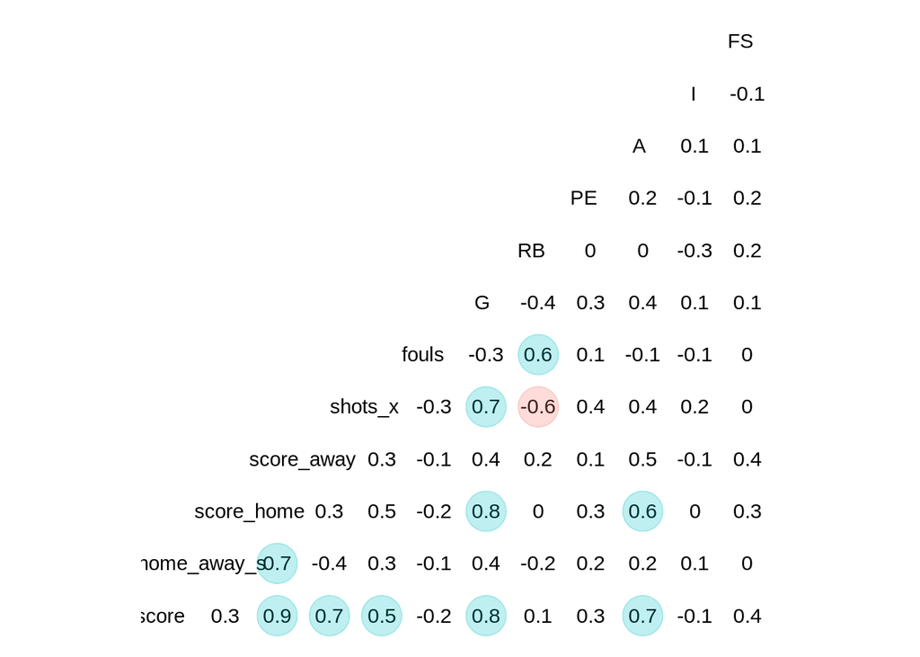

```r
# Selecionar variáveis de interesse para análise de agrupamento
data <-  cartola[, c("score_mean", "diff_home_away_s", "score_mean_home",
                     "score_mean_away",  "shots_x_mean", "fouls_mean", "G_mean",
                     "RB_mean",  "PE_mean", "A_mean", "I_mean", "FS_mean")]
names(data) <- gsub("_mean", "", names(data))
data <- dummify(data)

# Plotar matriz de correlação
ggcorr(data, geom = "blank", label = TRUE, hjust = 0.75) +
  geom_point(size = 10, aes(color = coefficient > 0, alpha = abs(coefficient) > 0.5)) +
  scale_alpha_manual(values = c("TRUE" = 0.25, "FALSE" = 0)) +
  guides(color = FALSE, alpha = FALSE)
```

Esta análise de correlação pode nos ajudar. Vamos começar com o geral - observe a última linha da figura acima. As variáveis mais associadas a média de pontos são: as médias de gol (0,8), assistência (0,7), chutes a gol (0,5) e faltas sofridas (0,4). Onde estão as roubadas de bola?

Boa pergunta. A associação é muito fraca (0,1), o que mostra que, de maneira geral, meias que roubam muitas bolas não necessariamente apresentam boa pontuação no cartola. Por quê? Duas outras variáveis nos ajudam a explicar porque os meias que roubam bolas não possuem boa pontuação. Primeiro, geralmente ladrões de bola fazem mais faltas, e o algoritmo do Cartola pune quem comete faltas. Segundo, roubadas de bola possuem associação negativa (-0,6) com chutes a gol. Isto é jogadores que roubam bolas precisam gastar mais energia na defesa.

Estes resultados convergem com as intuições dos cartoleiros experientes. É o que @mario_gomide do [Cartola PFC](https://www.cartolapfc.com.br) diz. Mario acompanha há dois anos as escalações de influenciadores de mais de 100 canais do Youtube. Ele disse que aproximadamente 1/4 apenas dos melhores cartoleiros influenciadores gostam de escalar jogadores que roubam bolas no meio de campo. Quando os cartoleiros mais experientes escalam um ladrão, também fazem questão que este tenha funções ofensivas como por exemplo, o Zé Rafael, antigo Bahia e agora Palmeiras. Na temporada passada, Zé Rafael era um mito no Cartola e com a mudança de função no Palmeiras, acabou desaparecendo das escalações. Vamos agora analisar os grupos de jogadores e tentar definir jogadores que possuem características semelhantes.

### Análise de agrupamentos

```r
# Criar matriz com escalonamento multidimensional
mds <-
  data %>%
  dist() %>%
  cmdscale() %>%
  as_tibble(.name_repair = "unique")
colnames(mds) <- c("Dim.1", "Dim.2")

# Preparar dados para algoritmo de propagação por afinidade.
datacluster <- dist(data)
datacluster <- as.matrix(datacluster)
apmodel     <- apcluster(negDistMat(r = 2), datacluster)
mds$cluster <- as.factor(apcluster::labels(apmodel, type = "enum"))
cartola$cluster <- as.factor(apcluster::labels(apmodel, type = "enum"))
```

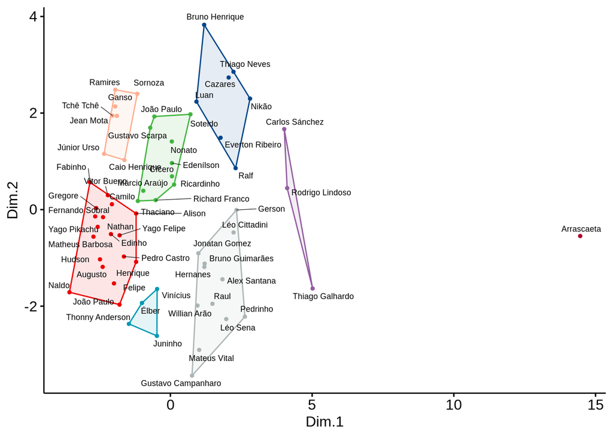

```r
# Plotar scatter
ggscatter(mds,
          x = "Dim.1",
          y = "Dim.2",
          label = cartola$player_nickname,
          color = "cluster",
          palette = "lancet",
          font.label = c(7, "plain", "black"),
          size = 1,
          ellipse = TRUE,
          ellipse.type = "convex",
          repel = TRUE) +
  theme(legend.position = "none")
```

## Análise

### Temos um Deus; Ele fala espanhol.

Ao analisar a figura acima, podemos perceber os agrupamentos criados pelo algoritmo. Temos ao total 8 agrupamentos de jogadores. Arrascaeta constitui um agrupamento porque vive num diferente planeta de pontuação no Cartola. A média de pontuação do uruguaio é de 11,7; 5,4 pontos distantes do segundo melhor meiocampo! Surreal.

Deixando Deus de lado, vamos tentar identificar interpretar as dimensões do gráfico. Para isso vamos comparar os dados abaixo e a figura acima.

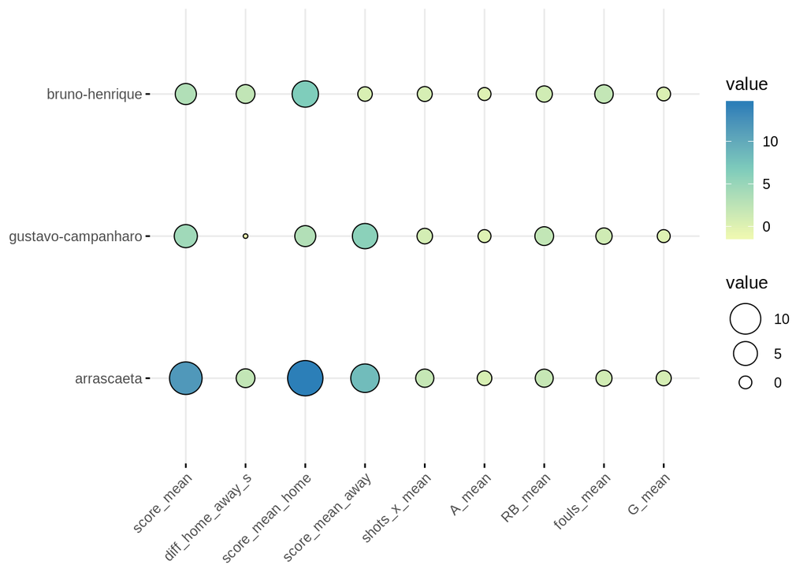

```r
tb <-
  cartola %>%
  filter(player_slug %in% c("bruno-henrique", "arrascaeta", "gustavo-campanharo") &
           score_mean > 2) %>%
  select(player_slug, score_mean, diff_home_away_s,
         score_mean_home, score_mean_away, shots_x_mean,
         A_mean, RB_mean, fouls_mean, G_mean)
plot <- tb[, -1]
row.names(plot) <- tb$player_slug

ggballoonplot(plot, fill = "value") +
  gradient_fill(c(brewer.pal(n = 3, name = "YlGnBu")))
```

Eixo X está fortemente composto pela média de pontos e Y pela média de pontos dentro de casa.

### Interpretação dos agrupamentos

Enquanto Carlos Sanchéz, Rodrigo Lindoso e Thiago Garlhado (em roxo) constituem o grupo de mortais com melhor desempenho no Cartola, no agrupamento azul, temos meias que pontuam bem em casa. Neste mesmo agrupamento azul, temos jogadores de características distintas tais como: Ralf e Thiago Neves. A observação deste agrupamento nos ajuda a entender que ladrõesw, fazem mais faltas e tendem a chutar menos, ilustrando o fênomeno que identificamos na matriz de correlação.

Por fim, no agrupamento cinza claro, temos meias que não possuem tanta variação de desempenho quando jogam em casa ou fora.

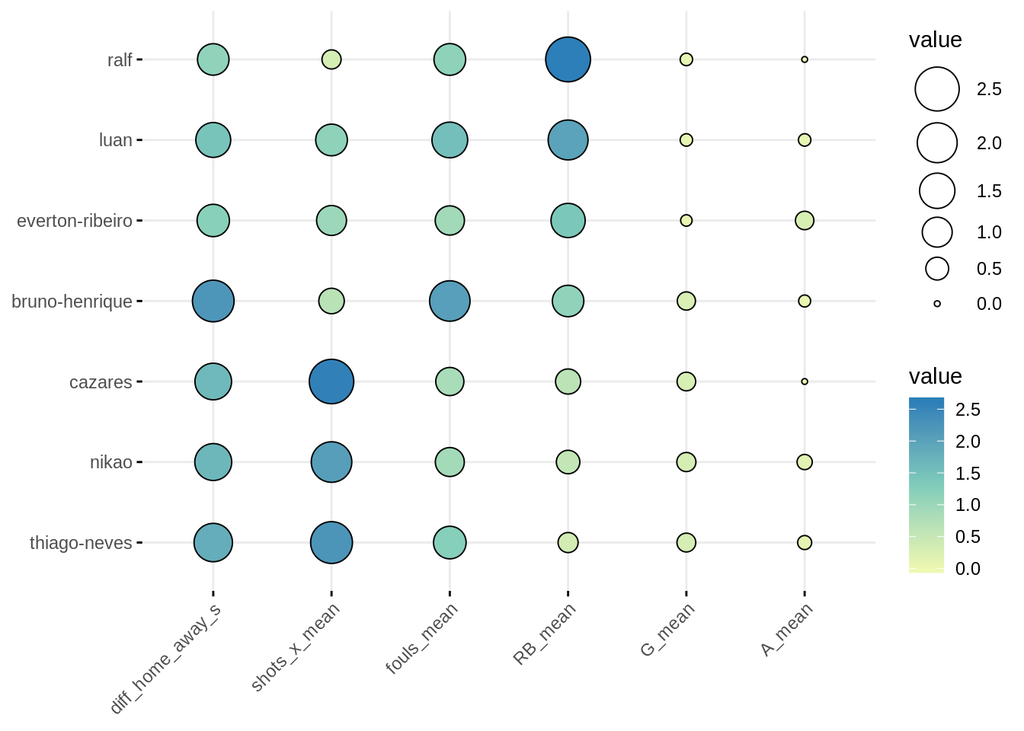

```r
tb <-
  cartola %>%
  filter(cluster == 1) %>%
  select(player_slug, diff_home_away_s,
         shots_x_mean, fouls_mean, RB_mean,
         G_mean, A_mean) %>%
  arrange(desc(RB_mean))

plot <- tb[, -1]
row.names(plot) <- tb$player_slug
ggballoonplot(plot, fill = "value") +
  gradient_fill(c(brewer.pal(n = 3, name = "YlGnBu")))
```

## Conclusões

Serei curto e breve:

1. Volantes podem ganhar um campeonato, mas não o Cartola. Prefira meias que possuem estatísticas de ataque.
2. Analise os confrontos da rodada (quem joga em casa, fora) para escolher atletas.

Deixe seu aplauso para que eu escrever a próxima e última análise. Laterais, Zagueiros e Goleiros.

H.G. :)